# Problem 1:Analysis of variance (ANOVA)

### The staff of a service center for electrical appliances include three technicians who specialize in repairing three widely used electrical appliances by three different manufacturers. It was desired to study the effects of Technician and Manufacturer on the service time. Each technician was randomly assigned five repair jobs on each manufacturer's appliance and the time to complete each job (in minutes) was recorded.

## Data Description:

## Importing required packages:

```python
import numpy as np
import pandas as pd
import seaborn as sns
import matplotlib.pyplot as plt
from statsmodels.formula.api import ols      # For n-way ANOVA
from statsmodels.stats.anova import _get_covariance,anova_lm # For n-way ANOVA
%matplotlib inline
from warnings import filterwarnings
filterwarnings('ignore')
```

## Data Description:

Technician- Three technicians who specialize in repairing

Manufacturer- Three widely used electrical appliances by three different manufacturers

Job-Each technician was randomly assigned five repair jobs on each manufacturer's appliance

Service_Time-time to complete each job (in minutes) was recorded

## Reading the Dataset:

```python
df=pd.read_csv('Service.csv')
```

## Checking the head and tail of Dataset:

```python
df.head(10)
```

|  | Technician | Manufacturer | Job | Service_Time |
| --- | --- | --- | --- | --- |
| 0 | 1 | 1 | 1 | 62 |
| 1 | 1 | 1 | 2 | 48 |
| 2 | 1 | 1 | 3 | 63 |
| 3 | 1 | 1 | 4 | 57 |
| 4 | 1 | 1 | 5 | 69 |
| 5 | 1 | 2 | 1 | 57 |
| 6 | 1 | 2 | 2 | 45 |
| 7 | 1 | 2 | 3 | 39 |
| 8 | 1 | 2 | 4 | 54 |
| 9 | 1 | 2 | 5 | 44 |

```python
df.tail()
```

|  | Technician | Manufacturer | Job | Service_Time |
| --- | --- | --- | --- | --- |
| 40 | 3 | 3 | 1 | 47 |
| 41 | 3 | 3 | 2 | 56 |
| 42 | 3 | 3 | 3 | 51 |
| 43 | 3 | 3 | 4 | 44 |
| 44 | 3 | 3 | 5 | 50 |

## Shape of Dataset:

```python
print('Number of rows:',df.shape[0])
print('Number of column:',df.shape[1])
```

```
Number of rows: 45
Number of column: 4
```

## Checking Info in Dataset:

```python
df.info()
```

```
<class 'pandas.core.frame.DataFrame'>
RangeIndex: 45 entries, 0 to 44
Data columns (total 4 columns):
 #   Column        Non-Null Count  Dtype
---  ------        --------------  -----
 0   Technician    45 non-null     int64
 1   Manufacturer  45 non-null     int64
 2   Job           45 non-null     int64
 3   Service_Time  45 non-null     int64
dtypes: int64(4)
memory usage: 1.5 KB
```

## Checking Null Values in Dataset:

```python
count=df.isnull().sum().sum()
print('Number of null values in Dataset:',count)
```

```
Number of null values in Dataset: 0
```

## Checking duplicates in dataset:

```python
dups=df.duplicated().sum()
print('number of duplicates:%d'%(dups))
```

```
number of duplicates:0
```

## Summary of Dataset:

```python
round(df.describe(include='all').T,2)
```

|  | count | mean | std | min | 25% | 50% | 75% | max |
| --- | --- | --- | --- | --- | --- | --- | --- | --- |
| Technician | 45.0 | 2.00 | 0.83 | 1.0 | 1.0 | 2.0 | 3.0 | 3.0 |
| Manufacturer | 45.0 | 2.00 | 0.83 | 1.0 | 1.0 | 2.0 | 3.0 | 3.0 |
| Job | 45.0 | 3.00 | 1.43 | 1.0 | 2.0 | 3.0 | 4.0 | 5.0 |
| Service_Time | 45.0 | 55.82 | 8.45 | 39.0 | 50.0 | 56.0 | 62.0 | 70.0 |

#### Observation:

Dataset consists 4 variables all are integer.

Dataset has 45 rows and 4 columns.

There is no null values and duplicates in dataset.

## Converting Integer Data type into Categorical:

```python
df['Technician']=pd.Categorical(df['Technician'])
df['Manufacturer']=pd.Categorical(df['Manufacturer'])
df['Job']=pd.Categorical(df['Job'])
```

```python
cols=['Technician','Manufacturer','Job']
for feature in cols:
    print(feature)
    count=df[feature].value_counts()
    print(count)
    print('\n')
```

```
Technician
3    15
2    15
1    15
Name: Technician, dtype: int64


Manufacturer
3    15
2    15
1    15
Name: Manufacturer, dtype: int64


Job
5    9
4    9
3    9
2    9
1    9
Name: Job, dtype: int64
```

### 1.1 State the Null and Alternate Hypothesis for conducting one-way ANOVA for both the variables ‘Manufacturer’ and ‘Technician individually.

#### Null and the Alternate hypothesis for Technician

H0 : Mean of Service_Time for all Technician is same

Ha: For at least one level of Technician mean is different

#### Null and the Alternate hypothesis for Manufacturer

H0 : Mean of Service_Time for all Manufacturer is same

Ha: For at least one level Manufacturer of mean is different

Lets assume significance level=0.05

### 1.2 Perform one-way ANOVA for variable ‘Manufacturer’ with respect to the variable ‘Service Time’. State whether the Null Hypothesis is accepted or rejected based on the ANOVA results.

```python
formula = 'Service_Time~ C(Manufacturer)'
model = ols(formula, df).fit()
aov_table = anova_lm(model)
(aov_table)
```

|  | df | sum_sq | mean_sq | F | PR(>F) |
| --- | --- | --- | --- | --- | --- |
| C(Manufacturer) | 2.0 | 28.311111 | 14.155556 | 0.191029 | 0.826822 |
| Residual | 42.0 | 3112.266667 | 74.101587 | NaN | NaN |

```python
from statsmodels.stats.multicomp import pairwise_tukeyhsd
```

```python
tukey=pairwise_tukeyhsd(endog=df['Service_Time'],groups=df['Manufacturer'],alpha=0.05)
print(tukey)
```

```
Multiple Comparison of Means - Tukey HSD, FWER=0.05
===================================================
group1 group2 meandiff p-adj   lower  upper  reject
---------------------------------------------------
     1      2   0.4667    0.9 -7.1696  8.103  False
     1      3     -1.4 0.8922 -9.0363 6.2363  False
     2      3  -1.8667 0.8077  -9.503 5.7696  False
---------------------------------------------------
```

#### Observation:

All the combinations mean differnce in Manufacturer is greater than 0.05 ie significance level hence we failed to reject the Null hypothesis.

### 3) Perform one-way ANOVA for variable ‘Technician’ with respect to the variable ‘Service Time’. State whether the Null Hypothesis is accepted or rejected based on the ANOVA results.

```python
formula = 'Service_Time~ C(Technician)'
model = ols(formula, df).fit()
aov_table = anova_lm(model)
(aov_table)
```

|  | df | sum_sq | mean_sq | F | PR(>F) |
| --- | --- | --- | --- | --- | --- |
| C(Technician) | 2.0 | 24.577778 | 12.288889 | 0.16564 | 0.847902 |
| Residual | 42.0 | 3116.000000 | 74.190476 | NaN | NaN |

```python
tukey=pairwise_tukeyhsd(endog=df['Service_Time'],groups=df['Technician'],alpha=0.05)
print(tukey)
```

```
Multiple Comparison of Means - Tukey HSD, FWER=0.05
===================================================
group1 group2 meandiff p-adj   lower  upper  reject
---------------------------------------------------
     1      2  -0.0667    0.9 -7.7075 7.5742  False
     1      3   1.5333 0.8682 -6.1075 9.1742  False
     2      3      1.6 0.8562 -6.0409 9.2409  False
---------------------------------------------------
```

#### Observation:

Since the p value is greater than the significance level(0.05), we failed to reject the null hupothesis and states that there is a no difference in the mean of Service_Time based on Technician.

All the combinations mean differnce in Technician is greater than 0.05 ie significance level hence we failed to reject the Null hypothesis.

### 4) Analyse the effects of one variable on another with the help of an interaction plot. What is an interaction between two treatments?

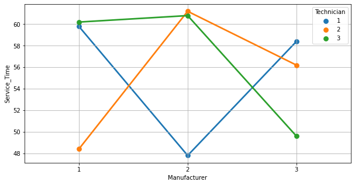

```python
plt.figure(figsize=(10,5))
sns.pointplot(x='Manufacturer', y='Service_Time', data=df, hue='Technician', ci=None)
plt.grid()
plt.show()
```

Observation:

There is good interaction between manufaturer and technician based on service time.

Tecnician 1 has low service time with manufacturer 2 when compare to all technicians and has high service time with manufacturer 3 when compared to all tecnicians.

Tecnician 2 with manufacturer 2 has high service time than all technicians and low service time with manufacure 1.

Technician 3 as high service time with manufacturer 1 & 2 and low with manufacturer 3.

### 5) Perform a two-way ANOVA based on the variables ‘Manufacturer’ & ‘Technician’ with respect to the variable ‘Service Time’ and state your results

There is good interaction between manufaturer and technician based on service time so we need to perform two-way ANOVA for better prediction.

#### C(Technician):C(Manufacturer)-Interaction Effect term

```python
formula = 'Service_Time~ C(Technician) + C(Manufacturer) + C(Technician):C(Manufacturer)'
model = ols(formula, df).fit()
aov_table = anova_lm(model)
(aov_table)
```

|  | df | sum_sq | mean_sq | F | PR(>F) |
| --- | --- | --- | --- | --- | --- |
| C(Technician) | 2.0 | 24.577778 | 12.288889 | 0.236274 | 0.790779 |
| C(Manufacturer) | 2.0 | 28.311111 | 14.155556 | 0.272164 | 0.763283 |
| C(Technician):C(Manufacturer) | 4.0 | 1215.288889 | 303.822222 | 5.841487 | 0.000994 |
| Residual | 36.0 | 1872.400000 | 52.011111 | NaN | NaN |

```python
formula = 'Service_Time~ C(Technician) + C(Manufacturer) + C(Job)+ C(Technician):C(Manufacturer)'
model = ols(formula, df).fit()
aov_table = anova_lm(model)
(aov_table)
```

|  | df | sum_sq | mean_sq | F | PR(>F) |
| --- | --- | --- | --- | --- | --- |
| C(Technician) | 2.0 | 24.577778 | 12.288889 | 0.219439 | 0.804167 |
| C(Manufacturer) | 2.0 | 28.311111 | 14.155556 | 0.252772 | 0.778181 |
| C(Job) | 4.0 | 80.355556 | 20.088889 | 0.358721 | 0.836042 |
| C(Technician):C(Manufacturer) | 4.0 | 1215.288889 | 303.822222 | 5.425262 | 0.001887 |
| Residual | 32.0 | 1792.044444 | 56.001389 | NaN | NaN |

#### Observation:

Since the p value is greater than the significance level(0.05), we failed to reject the null hupothesis and states that there is a no difference in the mean of Service_Time based on Technician,Manufacturer and jobs.

##### we see that the p-value of the interaction effect term of 'Technician' and 'Manufacturer' suggests that the Null Hypothesis is rejected in this case. So there is a difference in mean while interaction of both Technician and Manufacturer. Interaction term(C(Technician):C(Manufacturer)) has highest F-Value when comapred to Technician and Manufacturer.

### 6) Mention the business implications of performing ANOVA for this particular case study.

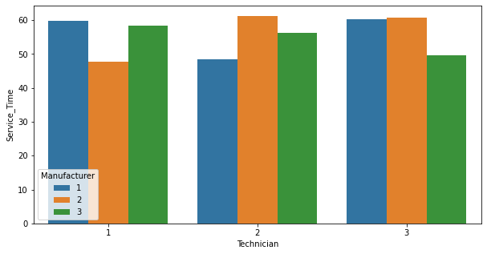

```python
plt.figure(figsize=(10,5))
sns.barplot(x='Technician',y='Service_Time',hue='Manufacturer',data=df,ci=False)
plt.show()
```

#### Observation:

Tecnician 1 has low service time with manufacturer 2 when compare to all technicians and has high service time with manufacturer 3 when compared to all tecnicians.

Tecnician 2 with manufacturer 2 has high service time than all technicians and low service time with manufacure 1.

Technician 3 as high service time with manufacturer 1 & 2 and low with manufacturer 3.

# Problem 2:Principal Component Analysis (PCA)

### Problem Statement: The ‘Hair Salon.csv’ dataset contains various variables used for the context of Market Segmentation. This particular case study is based on various parameters of a salon chain of hair products. You are expected to do Principal Component Analysis for this case study according to the instructions given in the following rubric.

## Data Description:

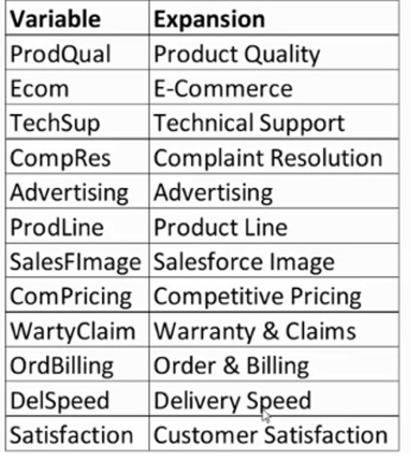

## Reading the Dataset:

```python
saloon=pd.read_csv('Hair Salon.csv')
```

## Checking the head and tail of Dataset:

```python
saloon.head()
```

|  | ID | ProdQual | Ecom | TechSup | CompRes | Advertising | ProdLine | SalesFImage | ComPricing | WartyClaim | OrdBilling | DelSpeed | Satisfaction |
| --- | --- | --- | --- | --- | --- | --- | --- | --- | --- | --- | --- | --- | --- |
| 0 | 1 | 8.5 | 3.9 | 2.5 | 5.9 | 4.8 | 4.9 | 6.0 | 6.8 | 4.7 | 5.0 | 3.7 | 8.2 |
| 1 | 2 | 8.2 | 2.7 | 5.1 | 7.2 | 3.4 | 7.9 | 3.1 | 5.3 | 5.5 | 3.9 | 4.9 | 5.7 |
| 2 | 3 | 9.2 | 3.4 | 5.6 | 5.6 | 5.4 | 7.4 | 5.8 | 4.5 | 6.2 | 5.4 | 4.5 | 8.9 |
| 3 | 4 | 6.4 | 3.3 | 7.0 | 3.7 | 4.7 | 4.7 | 4.5 | 8.8 | 7.0 | 4.3 | 3.0 | 4.8 |
| 4 | 5 | 9.0 | 3.4 | 5.2 | 4.6 | 2.2 | 6.0 | 4.5 | 6.8 | 6.1 | 4.5 | 3.5 | 7.1 |

```python
saloon.tail()
```

|  | ID | ProdQual | Ecom | TechSup | CompRes | Advertising | ProdLine | SalesFImage | ComPricing | WartyClaim | OrdBilling | DelSpeed | Satisfaction |
| --- | --- | --- | --- | --- | --- | --- | --- | --- | --- | --- | --- | --- | --- |
| 95 | 96 | 8.6 | 4.8 | 5.6 | 5.3 | 2.3 | 6.0 | 5.7 | 6.7 | 5.8 | 4.9 | 3.6 | 7.3 |
| 96 | 97 | 7.4 | 3.4 | 2.6 | 5.0 | 4.1 | 4.4 | 4.8 | 7.2 | 4.5 | 4.2 | 3.7 | 6.3 |
| 97 | 98 | 8.7 | 3.2 | 3.3 | 3.2 | 3.1 | 6.1 | 2.9 | 5.6 | 5.0 | 3.1 | 2.5 | 5.4 |
| 98 | 99 | 7.8 | 4.9 | 5.8 | 5.3 | 5.2 | 5.3 | 7.1 | 7.9 | 6.0 | 4.3 | 3.9 | 6.4 |
| 99 | 100 | 7.9 | 3.0 | 4.4 | 5.1 | 5.9 | 4.2 | 4.8 | 9.7 | 5.7 | 3.4 | 3.5 | 6.4 |

#### Observation:

Dataset has 100 rows and 13 columns.

Dataset consists of 12 float datatype and one integer type.

Satisfaction is target or dependent variable in dataset.

## Shape of Dataset:

```python
print('Number of rows:',saloon.shape[0])
print('Number of column:',saloon.shape[1])
```

```
Number of rows: 100
Number of column: 13
```

## Checking Info in Dataset:

```python
saloon.info()
```

```
<class 'pandas.core.frame.DataFrame'>
RangeIndex: 100 entries, 0 to 99
Data columns (total 13 columns):
 #   Column        Non-Null Count  Dtype
---  ------        --------------  -----
 0   ID            100 non-null    int64
 1   ProdQual      100 non-null    float64
 2   Ecom          100 non-null    float64
 3   TechSup       100 non-null    float64
 4   CompRes       100 non-null    float64
 5   Advertising   100 non-null    float64
 6   ProdLine      100 non-null    float64
 7   SalesFImage   100 non-null    float64
 8   ComPricing    100 non-null    float64
 9   WartyClaim    100 non-null    float64
 10  OrdBilling    100 non-null    float64
 11  DelSpeed      100 non-null    float64
 12  Satisfaction  100 non-null    float64
dtypes: float64(12), int64(1)
memory usage: 10.3 KB
```

## Checking Null Values in Dataset:

```python
dups=saloon.duplicated().sum()
print('number of duplicates:%d'%(dups))
```

```
number of duplicates:0
```

```python
saloon.drop('ID',axis=1,inplace=True)
```

## Summary of Dataset:

```python
round(saloon.describe(include='all').T,2)
```

|  | count | mean | std | min | 25% | 50% | 75% | max |
| --- | --- | --- | --- | --- | --- | --- | --- | --- |
| ProdQual | 100.0 | 7.81 | 1.40 | 5.0 | 6.57 | 8.00 | 9.10 | 10.0 |
| Ecom | 100.0 | 3.67 | 0.70 | 2.2 | 3.27 | 3.60 | 3.92 | 5.7 |
| TechSup | 100.0 | 5.36 | 1.53 | 1.3 | 4.25 | 5.40 | 6.62 | 8.5 |
| CompRes | 100.0 | 5.44 | 1.21 | 2.6 | 4.60 | 5.45 | 6.32 | 7.8 |
| Advertising | 100.0 | 4.01 | 1.13 | 1.9 | 3.18 | 4.00 | 4.80 | 6.5 |
| ProdLine | 100.0 | 5.80 | 1.32 | 2.3 | 4.70 | 5.75 | 6.80 | 8.4 |
| SalesFImage | 100.0 | 5.12 | 1.07 | 2.9 | 4.50 | 4.90 | 5.80 | 8.2 |
| ComPricing | 100.0 | 6.97 | 1.55 | 3.7 | 5.88 | 7.10 | 8.40 | 9.9 |
| WartyClaim | 100.0 | 6.04 | 0.82 | 4.1 | 5.40 | 6.10 | 6.60 | 8.1 |
| OrdBilling | 100.0 | 4.28 | 0.93 | 2.0 | 3.70 | 4.40 | 4.80 | 6.7 |
| DelSpeed | 100.0 | 3.89 | 0.73 | 1.6 | 3.40 | 3.90 | 4.43 | 5.5 |
| Satisfaction | 100.0 | 6.92 | 1.19 | 4.7 | 6.00 | 7.05 | 7.62 | 9.9 |

#### Observation:

There is no null values and duplicates in dataset.

Means and Median of all features is almost same.

### 2.1 Perform Exploratory Data Analysis [both univariate and multivariate analysis to be performed]. The inferences drawn from this should be properly documented

### univariate Analysis:

```python
def univariateAnalysis_numeric(column):
    print("Description of " + column)
    print("----------------------------------------------------------------------------")
    print(saloon[column].describe())

    print("\n")

    plt.figure()
    print("Distribution of " + column)
    print("----------------------------------------------------------------------------")
    sns.distplot(saloon[column], kde=False, color='g');
    plt.show()

    plt.figure()
    print("BoxPlot of " + column)
    print("----------------------------------------------------------------------------")
    ax = sns.boxplot(x=saloon[column])
    plt.show()
```

```python
lstnumericcolumns = list(saloon.columns.values)
len(lstnumericcolumns)
```

```
12
```

```
Description of ProdQual
----------------------------------------------------------------------------
count    100.000000
mean       7.810000
std        1.396279
min        5.000000
25%        6.575000
50%        8.000000
75%        9.100000
max       10.000000
Name: ProdQual, dtype: float64


Distribution of ProdQual
----------------------------------------------------------------------------
```

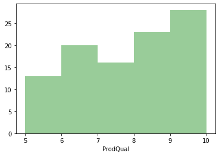

```
BoxPlot of ProdQual
----------------------------------------------------------------------------
```

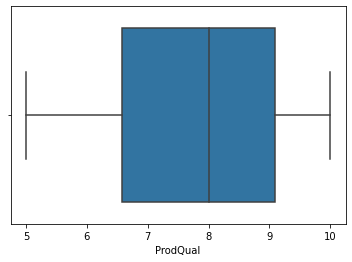

```
Description of Ecom
----------------------------------------------------------------------------
count    100.000000
mean       3.672000
std        0.700516
min        2.200000
25%        3.275000
50%        3.600000
75%        3.925000
max        5.700000
Name: Ecom, dtype: float64


Distribution of Ecom
----------------------------------------------------------------------------
```

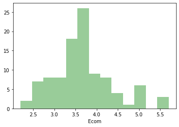

```
BoxPlot of Ecom
----------------------------------------------------------------------------
```

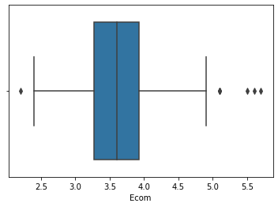

```
Description of TechSup
----------------------------------------------------------------------------
count    100.000000
mean       5.365000
std        1.530457
min        1.300000
25%        4.250000
50%        5.400000
75%        6.625000
max        8.500000
Name: TechSup, dtype: float64


Distribution of TechSup
----------------------------------------------------------------------------
```

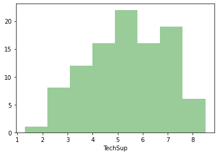

```
BoxPlot of TechSup
----------------------------------------------------------------------------
```

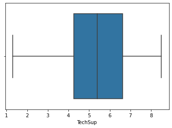

```
Description of CompRes
----------------------------------------------------------------------------
count    100.000000
mean       5.442000
std        1.208403
min        2.600000
25%        4.600000
50%        5.450000
75%        6.325000
max        7.800000
Name: CompRes, dtype: float64


Distribution of CompRes
----------------------------------------------------------------------------
```

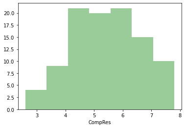

```
BoxPlot of CompRes
----------------------------------------------------------------------------
```

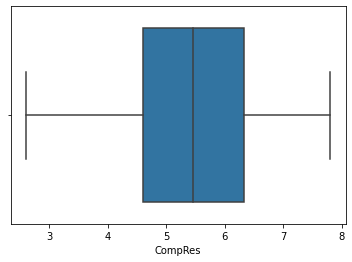

```
Description of Advertising
----------------------------------------------------------------------------
count    100.000000
mean       4.010000
std        1.126943
min        1.900000
25%        3.175000
50%        4.000000
75%        4.800000
max        6.500000
Name: Advertising, dtype: float64


Distribution of Advertising
----------------------------------------------------------------------------
```

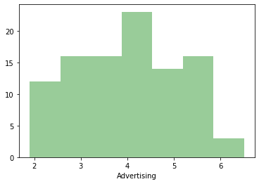

```
BoxPlot of Advertising
----------------------------------------------------------------------------
```

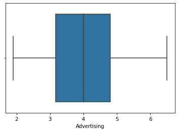

```
Description of ProdLine
----------------------------------------------------------------------------
count    100.000000
mean       5.805000
std        1.315285
min        2.300000
25%        4.700000
50%        5.750000
75%        6.800000
max        8.400000
Name: ProdLine, dtype: float64


Distribution of ProdLine
----------------------------------------------------------------------------
```

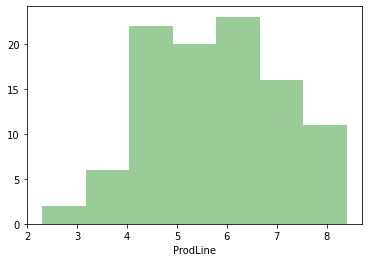

```
BoxPlot of ProdLine
----------------------------------------------------------------------------
```

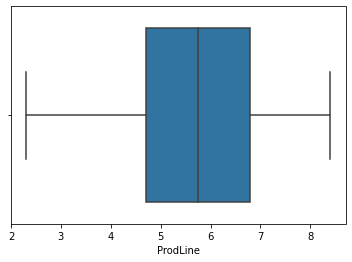

```
Description of SalesFImage
----------------------------------------------------------------------------
count    100.00000
mean       5.12300
std        1.07232
min        2.90000
25%        4.50000
50%        4.90000
75%        5.80000
max        8.20000
Name: SalesFImage, dtype: float64


Distribution of SalesFImage
----------------------------------------------------------------------------
```

[12 more figures not shown]

```python
for x in lstnumericcolumns:
    univariateAnalysis_numeric(x)
```

#### Observation:

There are 12 features in dataset all are float datatype.

Satisfaction is target or dependent variable in dataset.

Ecom,SalesFImage,Order & Billing,Delivery Speed has outliers in data.

Satisfaction from customers min is 4.7 and max is 9.9.

### Multivariate Analysis:

#### Pair Plot with Contineous Variable:

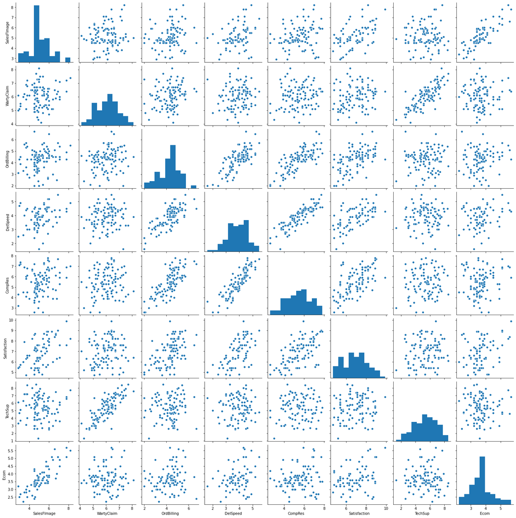

```python
sns.pairplot(saloon[['SalesFImage','WartyClaim','OrdBilling','DelSpeed','CompRes','Satisfaction','TechSup','Ecom']],diag_kind='hist')
plt.show()
```

#### Heatmap:

```python
corr = saloon.corr(method='pearson')
```

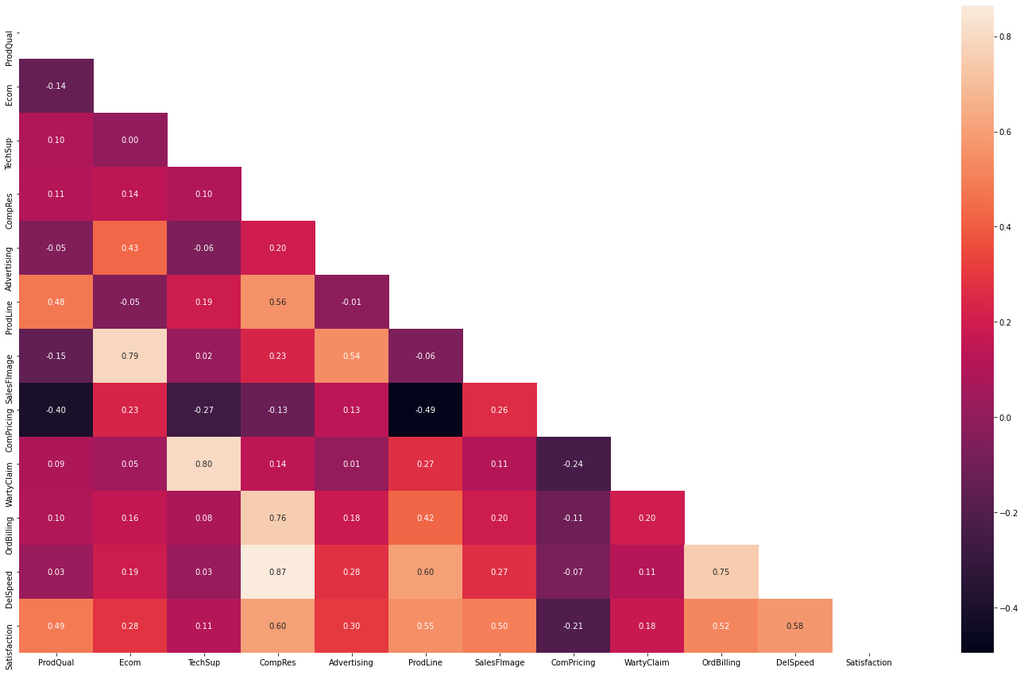

```python
mask = np.triu(np.ones_like(corr, dtype=np.bool))
fig = plt.subplots(figsize=(25, 15))
sns.heatmap(saloon.corr(), annot=True,fmt='.2f',mask=mask)
plt.show()
```

#### Observation:

Complaint resolution and delivery speed(0.87), Warrenty claim and Tech Support(0.80), Ecom and SalesFImage (0.79) which has positive correlation in decending order.

Competitive pricing and Tech support(-0.27),Competitive pricing and Product Quality(-0.40), Competitive pricing and product line(-0.49) which has top 3 negative correlation.

### Outlier Treatment:

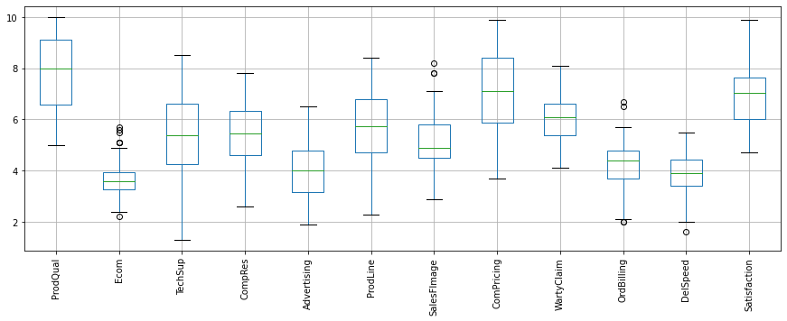

```python
saloon.boxplot(figsize=(15,5))
plt.xticks(rotation=90)
plt.show()
```

```python
def remove_outlier(col):
    sorted(col)
    Q1,Q3=np.percentile(col,[25,75])
    IQR=Q3-Q1
    lower_range= Q1-(1.5 * IQR)
    upper_range= Q3+(1.5 * IQR)
    return lower_range, upper_range
```

```python
lr,ur=remove_outlier(saloon['Ecom'])
print('Lower Range :',lr,'\nUpper Range :',ur)
saloon['Ecom']=np.where(saloon['Ecom']>ur,ur,saloon['Ecom'])
saloon['Ecom']=np.where(saloon['Ecom']<lr,lr,saloon['Ecom'])
```

```
Lower Range : 2.299999999999999
Upper Range : 4.9
```

```python
lr,ur=remove_outlier(saloon['SalesFImage'])
print('Lower Range :',lr,'\nUpper Range :',ur)
saloon['SalesFImage']=np.where(saloon['SalesFImage']>ur,ur,saloon['SalesFImage'])
saloon['SalesFImage']=np.where(saloon['SalesFImage']<lr,lr,saloon['SalesFImage'])
```

```
Lower Range : 2.5500000000000003
Upper Range : 7.75
```

```python
lr,ur=remove_outlier(saloon['OrdBilling'])
print('Lower Range :',lr,'\nUpper Range :',ur)
saloon['OrdBilling']=np.where(saloon['OrdBilling']>ur,ur,saloon['OrdBilling'])
saloon['OrdBilling']=np.where(saloon['OrdBilling']<lr,lr,saloon['OrdBilling'])
```

```
Lower Range : 2.0500000000000007
Upper Range : 6.449999999999999
```

```python
lr,ur=remove_outlier(saloon['DelSpeed'])
print('Lower Range :',lr,'\nUpper Range :',ur)
saloon['DelSpeed']=np.where(saloon['Ecom']>ur,ur,saloon['DelSpeed'])
saloon['DelSpeed']=np.where(saloon['DelSpeed']<lr,lr,saloon['DelSpeed'])
```

```
Lower Range : 1.8624999999999987
Upper Range : 5.962500000000002
```

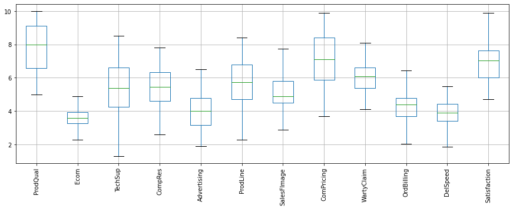

```python
saloon.boxplot(figsize=(15,5))
plt.xticks(rotation=90)
plt.show()
```

### 2.2 Scale the variables and write the inference for using the type of scaling function for this case study

```python
from scipy.stats import zscore
df_num_scaled=saloon.apply(zscore)
df_num_scaled.head()
```

|  | ProdQual | Ecom | TechSup | CompRes | Advertising | ProdLine | SalesFImage | ComPricing | WartyClaim | OrdBilling | DelSpeed | Satisfaction |
| --- | --- | --- | --- | --- | --- | --- | --- | --- | --- | --- | --- | --- |
| 0 | 0.496660 | 0.401668 | -1.881421 | 0.380922 | 0.704543 | -0.691530 | 0.838627 | -0.113185 | -1.646582 | 0.791872 | -0.260903 | 1.081067 |
| 1 | 0.280721 | -1.495974 | -0.174023 | 1.462141 | -0.544014 | 1.600835 | -1.917200 | -1.088915 | -0.665744 | -0.411249 | 1.398918 | -1.027098 |
| 2 | 1.000518 | -0.389017 | 0.154322 | 0.131410 | 1.239639 | 1.218774 | 0.648570 | -1.609304 | 0.192489 | 1.229371 | 0.845644 | 1.671354 |
| 3 | -1.014914 | -0.547153 | 1.073690 | -1.448834 | 0.615361 | -0.844354 | -0.586801 | 1.187789 | 1.173327 | 0.026250 | -1.229132 | -1.786038 |
| 4 | 0.856559 | -0.389017 | -0.108354 | -0.700298 | -1.614207 | 0.149004 | -0.586801 | -0.113185 | 0.069885 | 0.244999 | -0.537540 | 0.153474 |

#### Observation:

Normalisation is used to transform all variables in the data to a same range. It doesn't solve the problem caused by outliers. So, as you can see the after normalisation also, the outliers remains outliers. Only the range is changed.

Sacling should be done to center data before performing PCA since the transformation relies on the data being around the origin. Some data might already follow a standard normal distribution with mean zero and standard deviation of one and so would not have to be scaled before PCA.So PCA will not give accurate results.

### 2.3 Comment on the comparison between covariance and the correlation matrix after scaling

```python
df_num_scaled.cov()
```

|  | ProdQual | Ecom | TechSup | CompRes | Advertising | ProdLine | SalesFImage | ComPricing | WartyClaim | OrdBilling | DelSpeed | Satisfaction |
| --- | --- | --- | --- | --- | --- | --- | --- | --- | --- | --- | --- | --- |
| ProdQual | 1.010101 | -0.163220 | 0.096566 | 0.107444 | -0.054013 | 0.482317 | -0.147978 | -0.405335 | 0.089204 | 0.103531 | 0.024577 | 0.491237 |
| Ecom | -0.163220 | 1.010101 | -0.018976 | 0.110490 | 0.429417 | -0.097316 | 0.787115 | 0.270772 | 0.027657 | 0.147985 | 0.169845 | 0.244305 |
| TechSup | 0.096566 | -0.018976 | 1.010101 | 0.097633 | -0.063505 | 0.194571 | 0.009936 | -0.273522 | 0.805220 | 0.086307 | 0.029190 | 0.113735 |
| CompRes | 0.107444 | 0.110490 | 0.097633 | 1.010101 | 0.198906 | 0.567088 | 0.228937 | -0.129247 | 0.141827 | 0.765652 | 0.877623 | 0.609356 |
| Advertising | -0.054013 | 0.429417 | -0.063505 | 0.198906 | 1.010101 | -0.011667 | 0.548407 | 0.135573 | 0.010901 | 0.189904 | 0.275730 | 0.307747 |
| ProdLine | 0.482317 | -0.097316 | 0.194571 | 0.567088 | -0.011667 | 1.010101 | -0.063216 | -0.499948 | 0.275836 | 0.428152 | 0.606336 | 0.556107 |
| SalesFImage | -0.147978 | 0.787115 | 0.009936 | 0.228937 | 0.548407 | -0.063216 | 1.010101 | 0.273986 | 0.101972 | 0.196662 | 0.273952 | 0.506129 |
| ComPricing | -0.405335 | 0.270772 | -0.273522 | -0.129247 | 0.135573 | -0.499948 | 0.273986 | 1.010101 | -0.247461 | -0.114463 | -0.070999 | -0.210400 |
| WartyClaim | 0.089204 | 0.027657 | 0.805220 | 0.141827 | 0.010901 | 0.275836 | 0.101972 | -0.247461 | 1.010101 | 0.200107 | 0.117342 | 0.179338 |
| OrdBilling | 0.103531 | 0.147985 | 0.086307 | 0.765652 | 0.189904 | 0.428152 | 0.196662 | -0.114463 | 0.200107 | 1.010101 | 0.759896 | 0.526590 |
| DelSpeed | 0.024577 | 0.169845 | 0.029190 | 0.877623 | 0.275730 | 0.606336 | 0.273952 | -0.070999 | 0.117342 | 0.759896 | 1.010101 | 0.583217 |
| Satisfaction | 0.491237 | 0.244305 | 0.113735 | 0.609356 | 0.307747 | 0.556107 | 0.506129 | -0.210400 | 0.179338 | 0.526590 | 0.583217 | 1.010101 |

```python
df_num_scaled.corr()
```

|  | ProdQual | Ecom | TechSup | CompRes | Advertising | ProdLine | SalesFImage | ComPricing | WartyClaim | OrdBilling | DelSpeed | Satisfaction |
| --- | --- | --- | --- | --- | --- | --- | --- | --- | --- | --- | --- | --- |
| ProdQual | 1.000000 | -0.161588 | 0.095600 | 0.106370 | -0.053473 | 0.477493 | -0.146498 | -0.401282 | 0.088312 | 0.102495 | 0.024332 | 0.486325 |
| Ecom | -0.161588 | 1.000000 | -0.018786 | 0.109386 | 0.425123 | -0.096342 | 0.779244 | 0.268064 | 0.027380 | 0.146505 | 0.168147 | 0.241862 |
| TechSup | 0.095600 | -0.018786 | 1.000000 | 0.096657 | -0.062870 | 0.192625 | 0.009836 | -0.270787 | 0.797168 | 0.085443 | 0.028898 | 0.112597 |
| CompRes | 0.106370 | 0.109386 | 0.096657 | 1.000000 | 0.196917 | 0.561417 | 0.226647 | -0.127954 | 0.140408 | 0.757995 | 0.868846 | 0.603263 |
| Advertising | -0.053473 | 0.425123 | -0.062870 | 0.196917 | 1.000000 | -0.011551 | 0.542923 | 0.134217 | 0.010792 | 0.188005 | 0.272973 | 0.304669 |
| ProdLine | 0.477493 | -0.096342 | 0.192625 | 0.561417 | -0.011551 | 1.000000 | -0.062584 | -0.494948 | 0.273078 | 0.423870 | 0.600272 | 0.550546 |
| SalesFImage | -0.146498 | 0.779244 | 0.009836 | 0.226647 | 0.542923 | -0.062584 | 1.000000 | 0.271246 | 0.100953 | 0.194695 | 0.271213 | 0.501068 |
| ComPricing | -0.401282 | 0.268064 | -0.270787 | -0.127954 | 0.134217 | -0.494948 | 0.271246 | 1.000000 | -0.244986 | -0.113318 | -0.070289 | -0.208296 |
| WartyClaim | 0.088312 | 0.027380 | 0.797168 | 0.140408 | 0.010792 | 0.273078 | 0.100953 | -0.244986 | 1.000000 | 0.198106 | 0.116168 | 0.177545 |
| OrdBilling | 0.102495 | 0.146505 | 0.085443 | 0.757995 | 0.188005 | 0.423870 | 0.194695 | -0.113318 | 0.198106 | 1.000000 | 0.752298 | 0.521324 |
| DelSpeed | 0.024332 | 0.168147 | 0.028898 | 0.868846 | 0.272973 | 0.600272 | 0.271213 | -0.070289 | 0.116168 | 0.752298 | 1.000000 | 0.577385 |
| Satisfaction | 0.486325 | 0.241862 | 0.112597 | 0.603263 | 0.304669 | 0.550546 | 0.501068 | -0.208296 | 0.177545 | 0.521324 | 0.577385 | 1.000000 |

#### Observation:

Covariance and Correlation measures aid in establishing this. Covariance brings about the variation across variables. We use covariance to measure how much two variables change with each other. We use correlation to determine how strongly linked two variables are to each other.

If you scale (z-score) your data then your covariance matrix is a correlation matrix.

### 2.4 Check the dataset for outliers before and after scaling. Draw your inferences from this exercise.

### Before Scaling

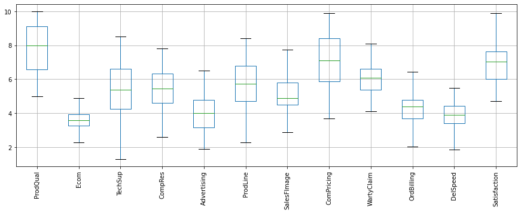

```python
saloon.boxplot(figsize=(15,5))
plt.xticks(rotation=90)
plt.show()
```

### After Scaling:

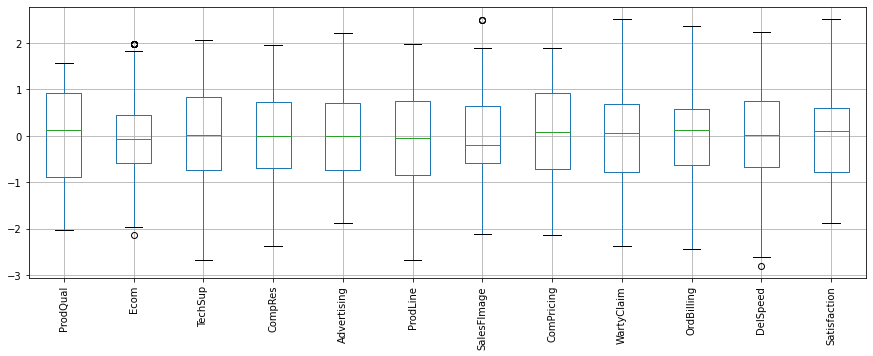

```python
df_num_scaled.boxplot(figsize=(15,5))
plt.xticks(rotation=90)
plt.show()
```

#### Obsevation:

Normalisation is used to transform all variables in the data to a same range. It doesn't solve the problem caused by outliers. So, as you can see the after normalisation also, the outliers remains outliers. Only the range is changed.

Removal of outliers creates a normal distribution in some of my variables, and makes transformations for the other variables more effective. Therefore, it seems that removal of outliers before transformation is the better option.

Compare the respective medians of each box plot. If the median line of a box plot lies outside of the box of a comparison box plot, then there is likely to be a difference between the two groups.

Sacling should be done to center data before performing PCA since the transformation relies on the data being around the origin. Some data might already follow a standard normal distribution with mean zero and standard deviation of one and so would not have to be scaled before PCA.So PCA will not give accurate results.

### 2.5 Build the covariance matrix, eigenvalues and eigenvector

```python
cov_matrix = np.cov(df_num_scaled.T)
print('Covariance Matrix \n%s', cov_matrix)
```

```
Covariance Matrix
%s [[ 1.01010101 -0.16322019  0.09656612  0.10744445 -0.05401327  0.48231658
  -0.14797813 -0.40533524  0.08920435  0.1035307   0.02457729  0.49123737]
 [-0.16322019  1.01010101 -0.01897569  0.11049041  0.42941698 -0.09731551
   0.78711486  0.27077209  0.02765676  0.14798521  0.16984515  0.24430522]
 [ 0.09656612 -0.01897569  1.01010101  0.09763293 -0.06350512  0.19457117
   0.00993585 -0.2735219   0.80522013  0.08630654  0.0291897   0.11373452]
 [ 0.10744445  0.11049041  0.09763293  1.01010101  0.19890591  0.56708783
   0.22893666 -0.12924672  0.14182656  0.765652    0.87762252  0.60935617]
 [-0.05401327  0.42941698 -0.06350512  0.19890591  1.01010101 -0.01166749
   0.54840714  0.13557262  0.01090109  0.18990387  0.2757305   0.30774694]
 [ 0.48231658 -0.09731551  0.19457117  0.56708783 -0.01166749  1.01010101
  -0.06321578 -0.49994788  0.27583589  0.42815152  0.60633585  0.55610701]
 [-0.14797813  0.78711486  0.00993585  0.22893666  0.54840714 -0.06321578
   1.01010101  0.27398615  0.10197224  0.19666154  0.27395232  0.50612921]
 [-0.40533524  0.27077209 -0.2735219  -0.12924672  0.13557262 -0.49994788
   0.27398615  1.01010101 -0.24746066 -0.11446288 -0.07099859 -0.21039969]
 [ 0.08920435  0.02765676  0.80522013  0.14182656  0.01090109  0.27583589
   0.10197224 -0.24746066  1.01010101  0.20010743  0.11734188  0.1793382 ]
 [ 0.1035307   0.14798521  0.08630654  0.765652    0.18990387  0.42815152
   0.19666154 -0.11446288  0.20010743  1.01010101  0.75989649  0.52659031]
 [ 0.02457729  0.16984515  0.0291897   0.87762252  0.2757305   0.60633585
   0.27395232 -0.07099859  0.11734188  0.75989649  1.01010101  0.58321673]
 [ 0.49123737  0.24430522  0.11373452  0.60935617  0.30774694  0.55610701
   0.50612921 -0.21039969  0.1793382   0.52659031  0.58321673  1.01010101]]
```

```python
df_num_scaled.drop('Satisfaction',axis=1,inplace=True)
```

### Principle Component Analysis(PCA):

Principal Components represent the directions of the data that specify a maximum amount of variance i.e. the lines that capture most information present in the data.

Principal Components as new axes that provide the best angle to visualize and evaluate the data, in order that the difference between the observations is best visible.

```python
from sklearn.decomposition import PCA
pca = PCA(n_components=11, random_state=123)
df_pca = pca.fit_transform(df_num_scaled)
```

```python
#Extract eigen vectors
pca.components_
```

```
array([[-0.13862521, -0.13255163, -0.16169816, -0.47353676, -0.1761158 ,
        -0.39268125, -0.18960766,  0.15780895, -0.21620195, -0.44059722,
        -0.47527939],
       [-0.30616255,  0.46140667, -0.22578297,  0.03265571,  0.3640688 ,
        -0.27255203,  0.47203851,  0.40962005, -0.18553872,  0.04338501,
         0.08704893],
       [ 0.06709281, -0.22881574, -0.61626115,  0.20638388, -0.0906638 ,
         0.11796883, -0.23760663,  0.04673072, -0.60432141,  0.15770584,
         0.22342129],
       [ 0.64972486,  0.25658155, -0.18140816, -0.20421824,  0.33265598,
         0.20316157,  0.2349916 , -0.32936184, -0.17150521, -0.22900266,
        -0.19979577],
       [ 0.29035482,  0.40547352, -0.00914631,  0.02569798, -0.78168324,
         0.11128718,  0.19275175,  0.29415447, -0.01839439,  0.04402211,
        -0.03422493],
       [ 0.52977297, -0.30406454,  0.10842621,  0.03136166,  0.25830325,
        -0.10856804, -0.12869836,  0.69840604,  0.13820704,  0.10792548,
        -0.02355011],
       [ 0.19462811,  0.07519199, -0.00340068, -0.00843865, -0.04839602,
        -0.60704084, -0.03532911, -0.2994856 , -0.03912519,  0.66311709,
        -0.23097124],
       [ 0.13317007, -0.18938057,  0.41970237,  0.51401584, -0.07750325,
        -0.34374346,  0.2570409 , -0.10993275, -0.40542731, -0.36861759,
         0.05887779],
       [ 0.01183241, -0.52168045, -0.41237425,  0.01690441, -0.1574079 ,
        -0.0745044 ,  0.62078485, -0.08201505,  0.36496521, -0.02092733,
        -0.03612782],
       [ 0.08936578,  0.28195279, -0.38976411,  0.5056586 ,  0.02731564,
        -0.2654653 , -0.34636059, -0.06113765,  0.44586354, -0.33035426,
        -0.04538755],
       [ 0.17803864,  0.03622843, -0.01479579, -0.4104794 , -0.07704307,
        -0.35982333, -0.05636008, -0.10052761,  0.08293481, -0.16708542,
         0.78408613]])
```

```python
#the eigen values
pca.explained_variance_
```

```
array([3.44279526, 2.6122913 , 1.69477856, 1.09242995, 0.61718431,
       0.54958841, 0.40600754, 0.24943513, 0.21516867, 0.13335371,
       0.09807827])
```

```python
var_exp = pca.explained_variance_ratio_
```

```python
#Check the explained variance for each PC
#Note: Explained variance = (eigen value of each PC)/(sum of eigen values of all PCs)
pca.explained_variance_ratio_
```

```
array([0.30985157, 0.23510622, 0.15253007, 0.0983187 , 0.05554659,
       0.04946296, 0.03654068, 0.02244916, 0.01936518, 0.01200183,
       0.00882704])
```

### Bartletts Test of Sphericity

#### Bartlett's test of sphericity tests the hypothesis that the variables are uncorrelated in the population:

H0: All variables in the data are uncorrelated.

Ha: At least one pair of variables in the data are correlated.

```python
from factor_analyzer.factor_analyzer import calculate_bartlett_sphericity
chi_square_value,p_value=calculate_bartlett_sphericity(df_num_scaled)
round(p_value,2)
```

```
0.0
```

#### Observation:

If the null hypothesis cannot be rejected, then PCA is not advisable.

For our dataset p_value is 0.0 which is less than 0.05. Hence we can reject the Null Hypothesis and agree that there is at least one pair of variables in the data which are correlated. Hence, PCA is recommended.

### KMO Test

The Kaiser-Meyer-Olkin (KMO) - measure of sampling adequacy (MSA) is an index used to examine how appropriate PCA is.

```python
### from factor_analyzer.factor_analyzer import calculate_kmo
from factor_analyzer.factor_analyzer import calculate_kmo
```

```python
kmo_all,kmo_model=calculate_kmo(df_num_scaled)
round(kmo_model,2)
```

```
0.65
```

#### Observation:

The Kaiser-Meyer-Olkin (KMO) - measure of sampling adequacy (MSA) is an index used to examine how appropriate PCA is.

Generally, if MSA is less than 0.5, PCA is not recommended, since no reduction is expected. On the other hand, MSA > 0.7 is expected to provide a considerable reduction is the dimension and extraction of meaningful components.

```python
#Create a dataframe containing the loadings or coefficients of all PCs
df_extracted_loadings = pd.DataFrame(pca.components_.T,
                                     columns = ['PC1','PC2', 'PC3', 'PC4', 'PC5', 'PC6',
                                               'PC7','PC8', 'PC9', 'PC10', 'PC11'],
                                    index = df_num_scaled.columns)
```

```python
df_extracted_loadings
```

|  | PC1 | PC2 | PC3 | PC4 | PC5 | PC6 | PC7 | PC8 | PC9 | PC10 | PC11 |
| --- | --- | --- | --- | --- | --- | --- | --- | --- | --- | --- | --- |
| ProdQual | -0.138625 | -0.306163 | 0.067093 | 0.649725 | 0.290355 | 0.529773 | 0.194628 | 0.133170 | 0.011832 | 0.089366 | 0.178039 |
| Ecom | -0.132552 | 0.461407 | -0.228816 | 0.256582 | 0.405474 | -0.304065 | 0.075192 | -0.189381 | -0.521680 | 0.281953 | 0.036228 |
| TechSup | -0.161698 | -0.225783 | -0.616261 | -0.181408 | -0.009146 | 0.108426 | -0.003401 | 0.419702 | -0.412374 | -0.389764 | -0.014796 |
| CompRes | -0.473537 | 0.032656 | 0.206384 | -0.204218 | 0.025698 | 0.031362 | -0.008439 | 0.514016 | 0.016904 | 0.505659 | -0.410479 |
| Advertising | -0.176116 | 0.364069 | -0.090664 | 0.332656 | -0.781683 | 0.258303 | -0.048396 | -0.077503 | -0.157408 | 0.027316 | -0.077043 |
| ProdLine | -0.392681 | -0.272552 | 0.117969 | 0.203162 | 0.111287 | -0.108568 | -0.607041 | -0.343743 | -0.074504 | -0.265465 | -0.359823 |
| SalesFImage | -0.189608 | 0.472039 | -0.237607 | 0.234992 | 0.192752 | -0.128698 | -0.035329 | 0.257041 | 0.620785 | -0.346361 | -0.056360 |
| ComPricing | 0.157809 | 0.409620 | 0.046731 | -0.329362 | 0.294154 | 0.698406 | -0.299486 | -0.109933 | -0.082015 | -0.061138 | -0.100528 |
| WartyClaim | -0.216202 | -0.185539 | -0.604321 | -0.171505 | -0.018394 | 0.138207 | -0.039125 | -0.405427 | 0.364965 | 0.445864 | 0.082935 |
| OrdBilling | -0.440597 | 0.043385 | 0.157706 | -0.229003 | 0.044022 | 0.107925 | 0.663117 | -0.368618 | -0.020927 | -0.330354 | -0.167085 |
| DelSpeed | -0.475279 | 0.087049 | 0.223421 | -0.199796 | -0.034225 | -0.023550 | -0.230971 | 0.058878 | -0.036128 | -0.045388 | 0.784086 |

### Scree Plot to decide on the Number of PC'S:

A Scree plot always displays the Eigenvalues in a downward curve, ordering the eigenvalues from largest to smallest. According to the Scree test, the ”elbow” of the graph where the Eigenvalues seem to level off is found and factors or components to the left of this point should be retained as significant.

The Scree Plot is used to determine the number of Principal Components to keep in a Principal Component Analysis(PCA).

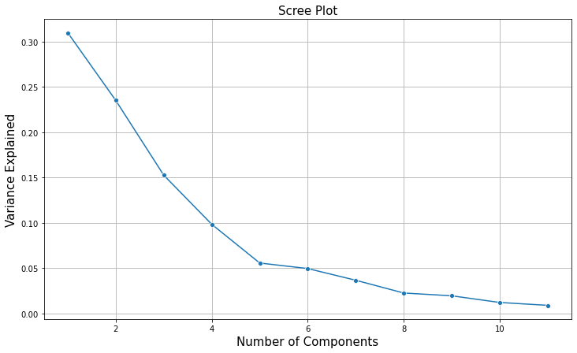

```python
plt.figure(figsize=(12,7))
sns.lineplot(y=var_exp,x=range(1,len(var_exp)+1),marker='o')
plt.xlabel('Number of Components',fontsize=15)
plt.ylabel('Variance Explained',fontsize=15)
plt.title('Scree Plot',fontsize=15)
plt.grid()
plt.show()
```

#### Observation:

we can see that it is basically an elbow-shaped graph.

Where in for our dataset up until 5 Principal Components there is a significant variation or change in the variance explained. So this by looking at the Scree Plot we can consider the number of Principal Components to be 5 for our dataset.

```python
df_pca_loading = pd.DataFrame(pca.components_,columns=list(df_num_scaled))
df_pca_loading.shape
```

```
(11, 11)
```

```python
df_pca_loading.head()
```

|  | ProdQual | Ecom | TechSup | CompRes | Advertising | ProdLine | SalesFImage | ComPricing | WartyClaim | OrdBilling | DelSpeed |
| --- | --- | --- | --- | --- | --- | --- | --- | --- | --- | --- | --- |
| 0 | -0.138625 | -0.132552 | -0.161698 | -0.473537 | -0.176116 | -0.392681 | -0.189608 | 0.157809 | -0.216202 | -0.440597 | -0.475279 |
| 1 | -0.306163 | 0.461407 | -0.225783 | 0.032656 | 0.364069 | -0.272552 | 0.472039 | 0.409620 | -0.185539 | 0.043385 | 0.087049 |
| 2 | 0.067093 | -0.228816 | -0.616261 | 0.206384 | -0.090664 | 0.117969 | -0.237607 | 0.046731 | -0.604321 | 0.157706 | 0.223421 |
| 3 | 0.649725 | 0.256582 | -0.181408 | -0.204218 | 0.332656 | 0.203162 | 0.234992 | -0.329362 | -0.171505 | -0.229003 | -0.199796 |
| 4 | 0.290355 | 0.405474 | -0.009146 | 0.025698 | -0.781683 | 0.111287 | 0.192752 | 0.294154 | -0.018394 | 0.044022 | -0.034225 |

Let's identify which features have maximum loading across the components.

We will first plot the component loading on a heatmap.

For each feature, we find the maximum loading value across the components and mark the same with help of rectangular box.

Features marked with rectangular red box are the one having maximum loading on the respective component. We consider these marked features to decide the context that the component represents.

```python
from matplotlib.patches import Rectangle
```

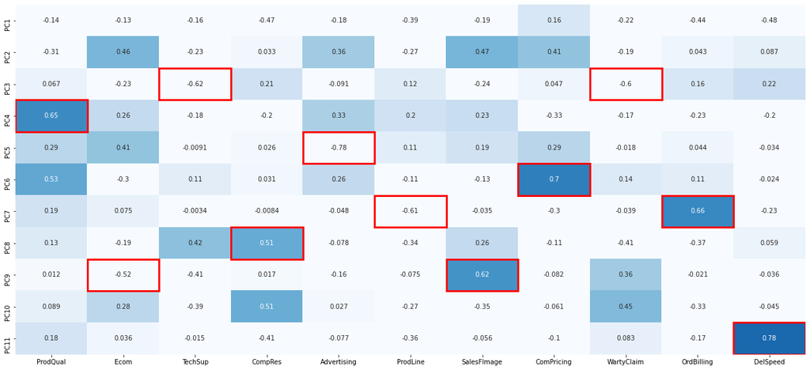

```python
fig,ax = plt.subplots(figsize=(22, 10), facecolor='w', edgecolor='k')
ax = sns.heatmap(df_pca_loading, annot=True, vmax=1.0, vmin=0, cmap='Blues', cbar=False, fmt='.2g', ax=ax,
                 yticklabels=['PC1','PC2', 'PC3', 'PC4', 'PC5', 'PC6',
                                               'PC7','PC8', 'PC9', 'PC10', 'PC11'])

column_max = df_pca_loading.abs().idxmax(axis=0)

for col, variable in enumerate(df_pca_loading.columns):
    position = df_pca_loading.index.get_loc(column_max[variable])
    ax.add_patch(Rectangle((col, position),1,1, fill=False, edgecolor='red', lw=3))
```

### 2.6 Write the explicit form of the first PC (in terms of Eigen Vectors)

#### Observation:

It shows how many times component 1(PC0) related to eachfeatures in dataset

### 2.7 Discuss the cumulative values of the eigenvalues. How does it help you to decide on the optimum number of principal components? What do the eigenvectors indicate? Perform PCA and export the data of the Principal Component scores into a data frame

### cumulative values of the eigenvalues:

```python
y = np.cumsum(pca.explained_variance_ratio_*100)
print('Cumulative Variance Explained:', y)
```

```
Cumulative Variance Explained: [ 30.98515733  54.49577899  69.74878605  79.58065556  85.13531437
  90.0816101   93.73567797  95.98059413  97.91711216  99.11729559
 100.        ]
```

### PCA For Optimal Numbers:

```python
#Apply PCA for the number of decided components to get the loadings and component output
# Using scikit learn PCA here. It does all the above steps and maps data to PCA dimensions in one shot
# NOTE - we are generating only 5 PCA dimensions (dimensionality reduction from 11 to 5)
pca = PCA(n_components=5, random_state=123)
df_pca = pca.fit_transform(df_num_scaled)
df_pca.transpose() # Component output
```

[output not shown]

[output cut: 115 more lines]

[output not shown]

```python
df_pca.shape
```

```
(100, 5)
```

```python
# Loading of each feature on the components
pca.components_
```

```
array([[-0.13862521, -0.13255163, -0.16169816, -0.47353676, -0.1761158 ,
        -0.39268125, -0.18960766,  0.15780895, -0.21620195, -0.44059722,
        -0.47527939],
       [-0.30616255,  0.46140667, -0.22578297,  0.03265571,  0.3640688 ,
        -0.27255203,  0.47203851,  0.40962005, -0.18553872,  0.04338501,
         0.08704893],
       [ 0.06709281, -0.22881574, -0.61626115,  0.20638388, -0.0906638 ,
         0.11796883, -0.23760663,  0.04673072, -0.60432141,  0.15770584,
         0.22342129],
       [ 0.64972486,  0.25658155, -0.18140816, -0.20421824,  0.33265598,
         0.20316157,  0.2349916 , -0.32936184, -0.17150521, -0.22900266,
        -0.19979577],
       [ 0.29035482,  0.40547352, -0.00914631,  0.02569798, -0.78168324,
         0.11128718,  0.19275175,  0.29415447, -0.01839439,  0.04402211,
        -0.03422493]])
```

```python
var_exp = pca.explained_variance_ratio_
```

```python
pca.explained_variance_
```

```
array([3.44279526, 2.6122913 , 1.69477856, 1.09242995, 0.61718431])
```

```python
#Check the explained variance for each PC
#Note: Explained variance = (eigen value of each PC)/(sum of eigen values of all PCs)
pca.explained_variance_ratio_
```

```
array([0.30985157, 0.23510622, 0.15253007, 0.0983187 , 0.05554659])
```

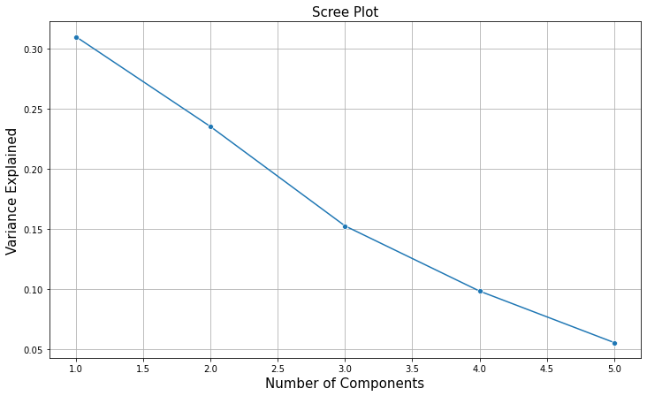

```python
#View Scree Plot to identify the number of components to be built
plt.figure(figsize=(12,7))
sns.lineplot(y=var_exp,x=range(1,len(var_exp)+1),marker='o')
plt.xlabel('Number of Components',fontsize=15)
plt.ylabel('Variance Explained',fontsize=15)
plt.title('Scree Plot',fontsize=15)
plt.grid()
plt.show()
```

```python
df_pca_loading_new = pd.DataFrame(pca.components_,columns=list(df_num_scaled))
df_pca_loading_new.shape
```

```
(5, 11)
```

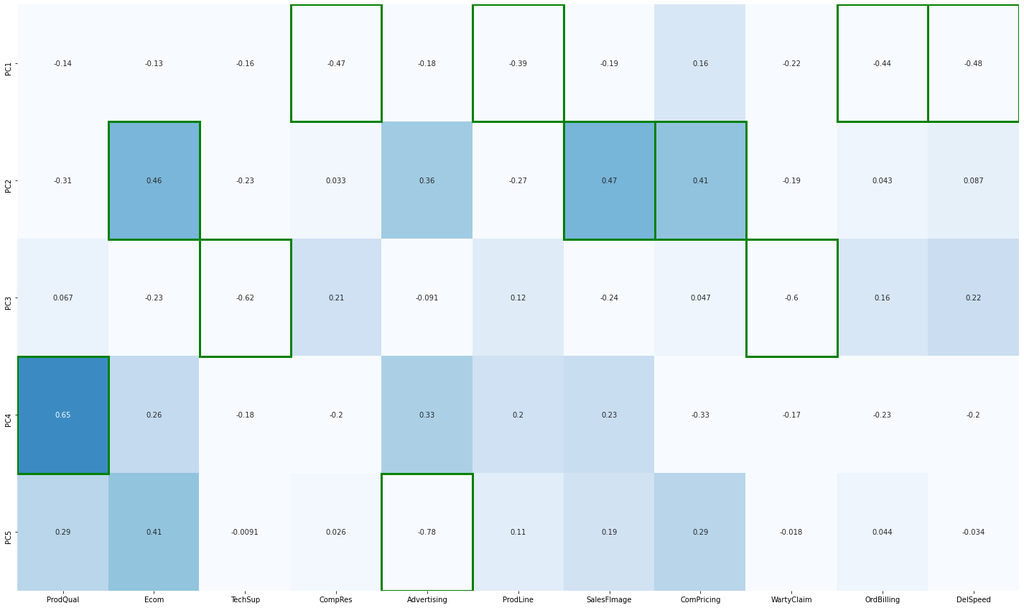

```python
fig,ax = plt.subplots(figsize=(25, 15), facecolor='w', edgecolor='k')
ax = sns.heatmap(df_pca_loading_new, annot=True, vmax=1.0, vmin=0, cmap='Blues', cbar=False, fmt='.2g', ax=ax,
                 yticklabels=['PC1','PC2','PC3','PC4','PC5'])

column_max = df_pca_loading_new.abs().idxmax(axis=0)

for col, variable in enumerate(df_pca_loading_new.columns):
    position = df_pca_loading_new.index.get_loc(column_max[variable])
    ax.add_patch(Rectangle((col, position),1,1, fill=False, edgecolor='green', lw=3))
```

#### Observation:

PC1 is the linear combination of feature CompRes,ProdLine,OrdBilling and DelSpeed.

PC2 is the linear combination of feature Ecom,SalesFImage,ComPricing.

PC3 is the linear combination of feature TechSup and WartyClaim.

PC4 has ProdQual.

PC5 has Advertising.

### New DataFrame using Principal Component scores:

```python
df_pca = pd.DataFrame(df_pca,columns=['product delivery','Marketing','Customer Support','ProdQual','Advertising'])
df_pca.head()
```

|  | product delivery | Marketing | Customer Support | ProdQual | Advertising |
| --- | --- | --- | --- | --- | --- |
| 0 | 0.103448 | 1.582136 | 1.891125 | 1.170678 | -0.091188 |
| 1 | -1.185740 | -2.447109 | 2.062983 | -0.487238 | -0.626093 |
| 2 | -2.233351 | -0.659052 | 0.156726 | 1.354350 | -1.025371 |
| 3 | 1.566514 | 0.108695 | -1.843592 | -1.156312 | -0.880650 |
| 4 | 0.733565 | -1.440923 | 0.243100 | 0.051372 | 1.233842 |

### 2.8 Mention the business implication of using the Principal Component Analysis for this case study.

Large datasets are increasingly common and are often difficult to interpret. Principal component analysis (PCA) is a technique for reducing the dimensionality of such datasets, increasing interpretability but at the same time minimizing information loss.

It does so by creating new uncorrelated variables that successively maximize variance. Finding such new variables, the principal components, reduces to solving an eigenvalue/eigenvector problem, and the new variables are defined by the dataset at hand, not a priority, hence making PCA an adaptive data analysis technique.

Customer need to engage with advertisement and promotional offers , so it will increase the revenue. we need to deep dive in to customer satisfaction who has given low rating and check which product they purchased. we should call the customer and get feedback from them.According to feedback from customers we need to analyse the product to retain the customer.

Low rating in product quality we need to coordinate with quality team and shuld take a call to increase the quality of product.